# Simple Linear Regression

## Background

Data was collected from a random participant with their permission. The data represents the max amount of pushup the participant can do per set, with multiple sets being done. The assumption is that the more sets done, the less pushups you can do. Through this study the following question was presented:

Is there a relationship between the max amount of pushups someone can do, and the number of sets they do?

Data Table (click to view)

**Hypothesis**

$$H_0: \beta_1 = 0$$
$$H_a: \beta_1 \neq 0$$

## Analysis

The scatter plot below represents the relationship between the number of pushups done and the set number.

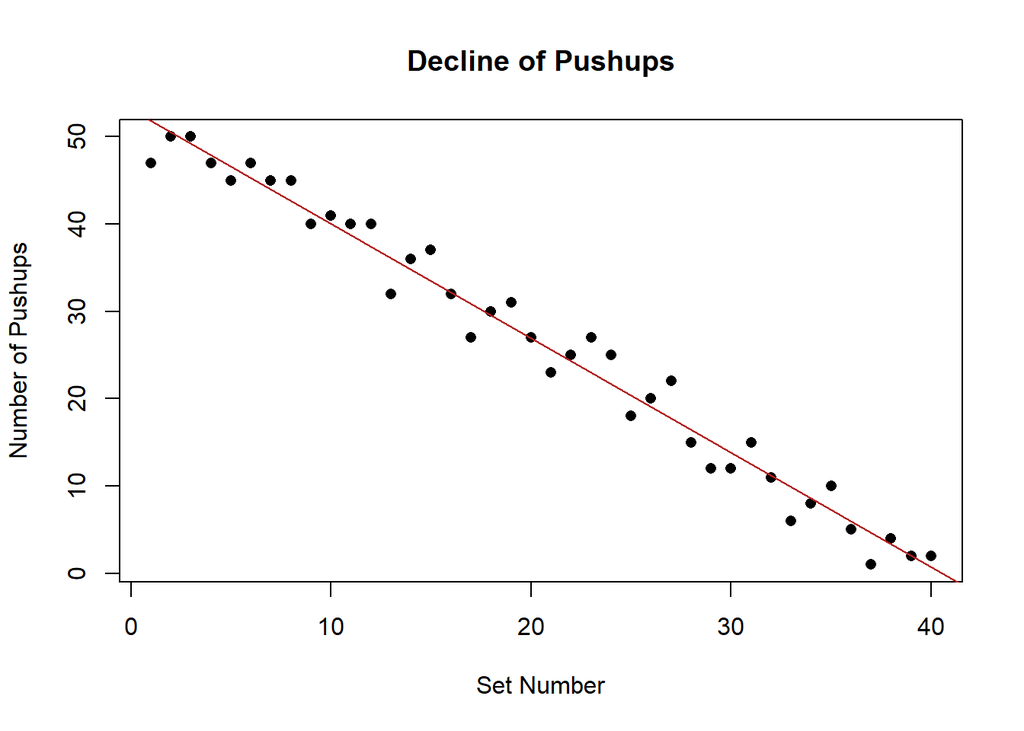

```r
plot(Pushups ~ DataVar, data = Data2.1, pch = 16, main = "Decline of Pushups", xlab = "Set Number", ylab = "Number of Pushups")
Data.lm <- lm(Pushups ~ DataVar, data = Data2.1)
abline(Data.lm, col = "firebrick")
```

**Regression Credability**

- The regression relation between `Y` and `X` is linear.
- The error terms are normally distributed with `E{ϵi}=0.`
- The variance of the error terms is constant over all `X` values.
- The `X` values can be considered fixed and measured without error.
- The error terms are `independent.`

Residuals vs Fitted (click to view)

Normal Q-Q (click to view)

Residuals vs Order (click to view)

**Linear Regression**

```r
pander(summary(Data.lm))
```

|  | Estimate | Std. Error | t value | Pr(>\|t\|) |
| --- | --- | --- | --- | --- |
| **(Intercept)** | 53.16 | 0.7774 | 68.39 | 2.144e-41 |
| **DataVar** | -1.31 | 0.03304 | -39.66 | 1.575e-32 |

Fitting linear model: Pushups ~ DataVar

| Observations | Residual Std. Error | $R^2$ | Adjusted $R^2$ |
| --- | --- | --- | --- |
| 40 | 2.412 | 0.9764 | 0.9758 |

The above table gives us the equation of the linear relationship between set number and pushups among other things.
$$y = -1.31x + 53.16$$

As presented in the table, as well, the pValue is very small ($p < .0001$). This tells us that there **is** a relationship between set number, and the amount of capable of being done.

## Interpretation

The data was proven to fit the requirements for a regression test, and a test was preformed. With the resulting p Value of $p < .001$ we concluded that there is sufficient evidence to reject the null. This data along with the linear equation provided makes it apparent that the max number of pushups decreases as the set number increases.